# Incidence of cancer in NHS Borders

Data Analysis using R

Lenka Rozborilova

4/2/2021

Following analysis is based on data available from The Scottish Health and Social Care Open Data platform, https://www.opendata.nhs.scot/dataset/annual-cancer-incidence

Upward trend in the incidences of cancer in NHS Borders between years 1994 and 2018:

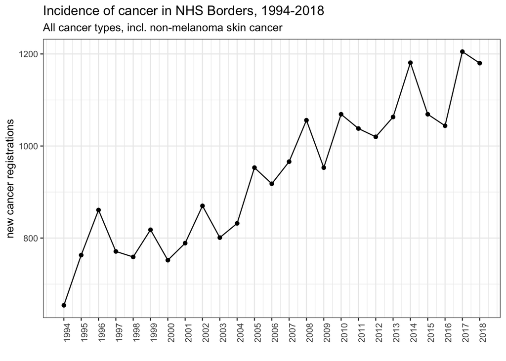

Number of all cancer registrations (incl. non-melanoma skin cancer) between years 1994 and 2018 (period of 25 years) was 23385.

Summary of all incidences of cancer diagnosed in NHS Borders, broken down by cancer sites for all ages and for both sexes throughout the years 1994 to 2018 (32 categories):

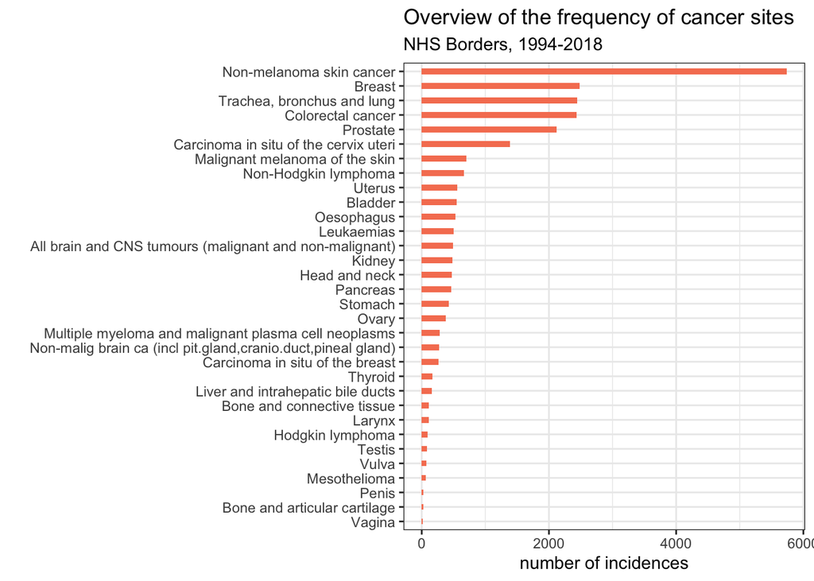

Note: Some of the cancer site categories also include sub-categories, please see the footnote for more detail:[^1]

**Number of cancer incidences for the six most common cancer sites diagnosed between years 1994 and 2018**

```
## # A tibble: 6 x 2
##   cancer_site                           total
##   <chr>                                 <dbl>
## 1 Non-melanoma skin cancer               5741
## 2 Breast                                 2483
## 3 Trachea, bronchus and lung             2441
## 4 Colorectal cancer                      2436
## 5 Prostate                               2119
## 6 Carcinoma in situ of the cervix uteri  1386
```

Non-melanoma skin cancer was the most diagnosed cancer site in the NHS Borders with Malignant melanoma being the 7th most diagnosed cancer site. Following graph is showing the Crude Rate[^2] of both types of skin cancer:

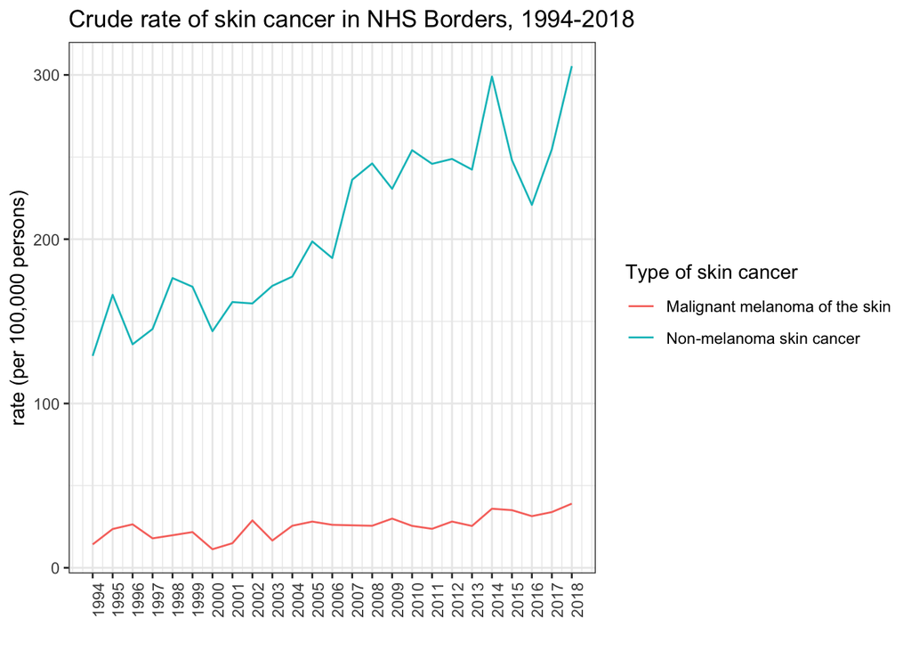

Crude rate and Standardised Incidence Ratio[^3] for the six **most common cancer sites** diagnosed between years 1994 and 2018:

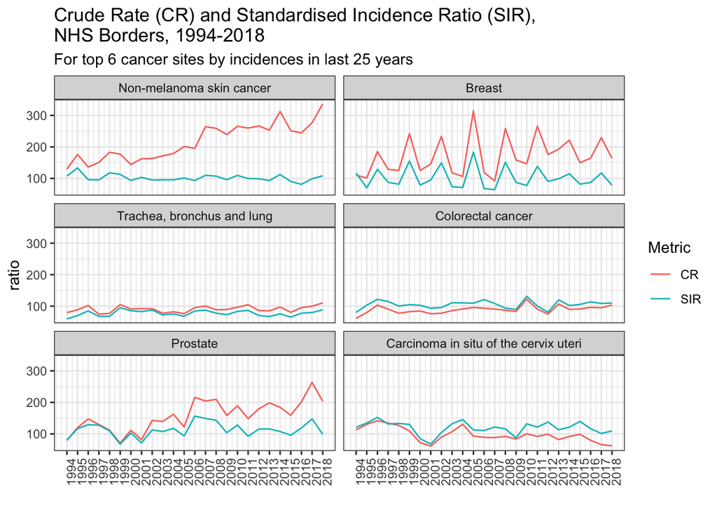

Crude rate and Standardised Incidence Ratio for the six cancer sites with the **most extreme SIR** in last 5 years (2013-2018) and visualised the rates again

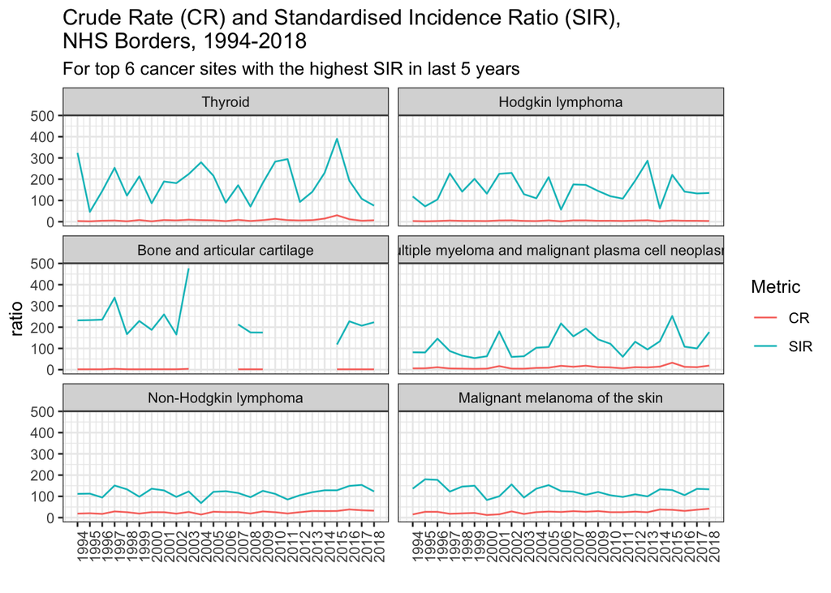

**Conclusion:** Based on the data analysis on incidences of cancer diagnosed in NHS Borders over the period of 25 years (1994-2018), I suggest to allocate future  
provision of cancer treatment services in NHS Borders focusing on cancer sites: * Thyroid * Hodgkin and Non-Hodgkin lymphoma * Bone and articular cartilage * Multiple myeloma and malignant plasma cell neoplasm.

Concidering the high frequency of skin cancer being diagnosed, I would also suggest to focus on increasing the awareness of this type of cancer among public as these are, in many cases, preventable types of cancer.

[^1]: Non-melanoma skin cancer (incl. Squamous cell carcinoma of the skin, Basal cell carcinoma of the skin); Colorectal cancer (incl. Colon, Rectum and rectosigmoid junction);  
    Uterus (incl. Cervix uteri, Corpus uteri);  
    Leukaemias (incl. Acute lymphoblastic leukaemia, Chronic lymphocytic leukaemia, Acute myeloid leukaemia, Chronic myeloid leukaemia);  
    All brain and CNS tumours (malignant and non-malignant) (incl. Malig brain ca (incl pit. gland, cranio. duct, pineal gland), Malignant brain cancer, Non-malig brain ca (incl pit.gland,cranio.duct,pineal gland));  
    Head and neck (incl. Lip, oral cavity and pharynx, Tongue, Oropharyngeal cancers, Mouth (IARC definition), Salivary glands);  
    Bone and connective tissue (incl. Connective tissue)
[^2]: calculated by dividing the number of new cancers observed during each year by the corresponding number of people in the population at risk
[^3]: obtained by dividing the observed number of cases of cancer by the “expected” number of cases, tells us if the number of observed cancer cases in a particular geographic area is higher or lower than expected